# p8105_hw6_aw3621

Anni Wang

2024-12-02

```r
library(rnoaa)
library(dplyr)
```

```r
library(ggplot2)
library(broom)
library(tidyverse)
library(p8105.datasets)
library(ggplot2)
library(modelr)
set.seed(1)
```

###Problem 1

```r
weather_df =
  rnoaa::meteo_pull_monitors(
    c("USW00094728"),
    var = c("PRCP", "TMIN", "TMAX"),
    date_min = "2017-01-01",
    date_max = "2017-12-31") %>%
  mutate(
    name = recode(id, USW00094728 = "CentralPark_NY"),
    tmin = tmin / 10,
    tmax = tmax / 10) %>%
  select(name, id, everything())
```

```
## using cached file: /Users/wanganni/Library/Caches/org.R-project.R/R/rnoaa/noaa_ghcnd/USW00094728.dly
```

```
## date created (size, mb): 2024-09-26 10:18:50.773147 (8.651)
```

```
## file min/max dates: 1869-01-01 / 2024-09-30
```

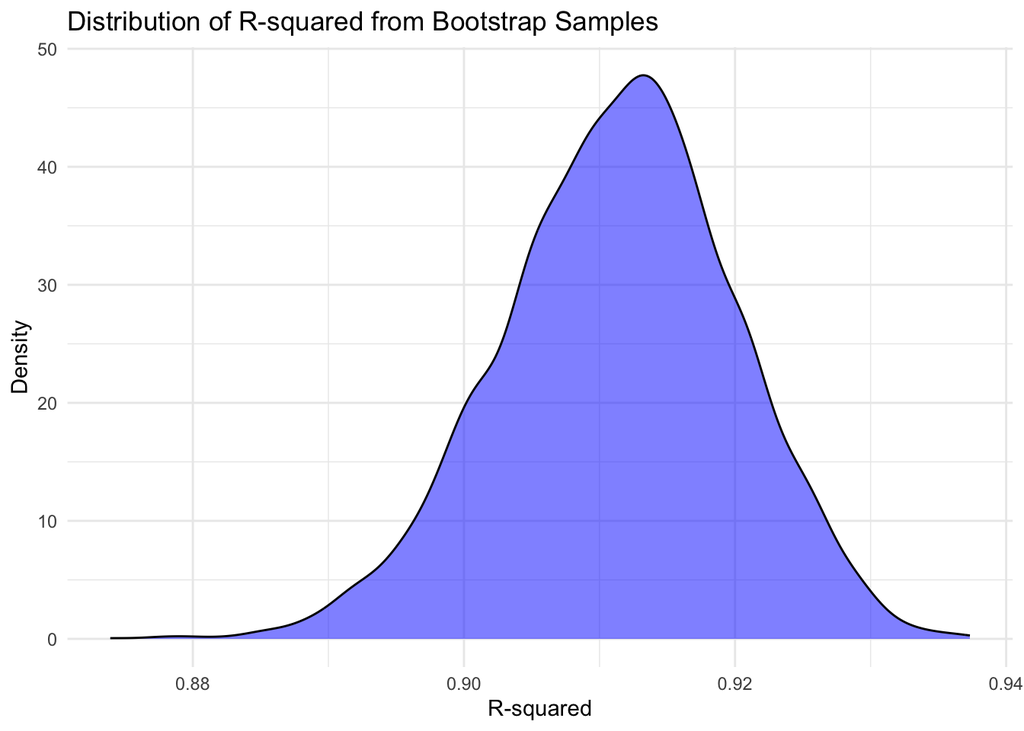

```r
bootstrap_samples <- modelr::bootstrap(weather_df, 5000)

bootstrap_results <- bootstrap_samples %>%
  mutate(
    model = map(strap, ~ lm(tmax ~ tmin, data = as_tibble(.x))),
    r_squared = map_dbl(model, ~ broom::glance(.x)[["r.squared"]]),
    log_coef_product = map_dbl(model, ~ {
      coef_vals <- broom::tidy(.x) %>% pull(estimate)
      log(coef_vals[1] * coef_vals[2])
    })
  )

# Plotting results
bootstrap_results %>%
  ggplot(aes(x = r_squared)) +
  geom_density(fill = "blue", alpha = 0.5) +
  labs(title = "Distribution of R-squared from Bootstrap Samples",
       x = "R-squared",
       y = "Density") +
  theme_minimal()
```

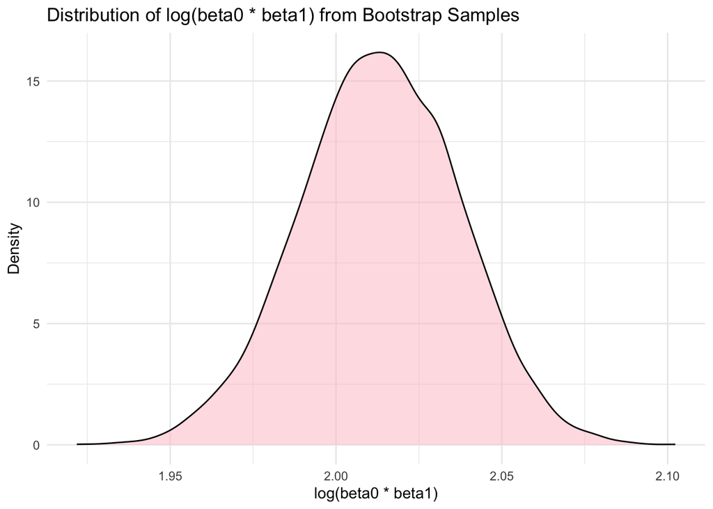

```r
bootstrap_results %>%
  ggplot(aes(x = log_coef_product)) +
  geom_density(fill = "pink", alpha = 0.5) +
  labs(title = "Distribution of log(beta0 * beta1) from Bootstrap Samples",
       x = "log(beta0 * beta1)",
       y = "Density") +
  theme_minimal()
```

```r
# Confidence intervals
ci_r_squared <- quantile(bootstrap_results %>% pull(r_squared), c(0.025, 0.975))
ci_log_coef_product <- quantile(bootstrap_results %>% pull(log_coef_product), c(0.025, 0.975))

print(paste("95% CI for R-squared:", ci_r_squared[1], "-", ci_r_squared[2]))
```

```
## [1] "95% CI for R-squared: 0.893668412197251 - 0.927105964467631"
```

```r
print(paste("95% CI for log(beta0 * beta1):", ci_log_coef_product[1], "-", ci_log_coef_product[2]))
```

```
## [1] "95% CI for log(beta0 * beta1): 1.9649486928301 - 2.05888745920792"
```

###Problem 2

```r
homicide_df = read_csv(file = "data/homicide-data.csv", na = c("Unknown", "NA", "")) |>
  mutate(reported_date = as.Date(as.character(reported_date), format = "%Y%m%d"))
#Create a city_state variable (e.g. “Baltimore, MD”), and a binary variable indicating whether the homicide is solved.Omit cities Dallas, TX; Phoenix, AZ; and Kansas City, MO – these don’t report victim race. Also omit Tulsa, AL
homicide_df <- homicide_df %>%
  mutate(
    city_state = str_c(city, state, sep = ", "),
    solved = if_else(disposition == "Closed by arrest", 1, 0),
    victim_age = as.numeric(victim_age)
  ) %>%
  filter(
    !city_state %in% c("Dallas, TX", "Phoenix, AZ", "Kansas City, MO", "Tulsa, AL"),
    victim_race %in% c("White", "Black")
  )
```

```r
##For the city of Baltimore, MD, use the glm function to fit a logistic regression with resolved vs unresolved as the outcome and victim age, sex and race as predictors.
baltimore_reg <- homicide_df |>
  filter(city_state == "Baltimore, MD")
logistic_model <- glm(solved ~ victim_age + victim_sex + victim_race,
                      data = baltimore_reg, family = binomial())
```

```r
##Save the output of glm as an R object; apply the broom::tidy to this object; and obtain the estimate and confidence interval of the adjusted odds ratio for solving homicides comparing male victims to female victims keeping all other variables fixed.
logistic_model %>%
  broom::tidy(conf.int = TRUE) %>%
  filter(term == "victim_sexMale") %>%
  mutate(
    OR = exp(estimate),
    CI_low = exp(conf.low),
    CI_high = exp(conf.high)
  ) |>
  select(OR, CI_low, CI_high)%>%
  knitr::kable(digits = 3)
```

| OR | CI_low | CI_high |
| --- | --- | --- |
| 0.426 | 0.324 | 0.558 |

OR=0.426 with 95%CI (0.324,0.558)

```r
##Now run glm for each of the cities in your dataset, and extract the adjusted odds ratio (and CI) for solving homicides comparing male victims to female victims. Do this within a “tidy” pipeline, making use of purrr::map, list columns, and unnest as necessary to create a dataframe with estimated ORs and CIs for each city.
eachcity <- homicide_df %>%
  group_by(city_state) %>%
  nest() %>%
  mutate(
    model = map(data, ~ glm(solved ~ victim_age + victim_sex + victim_race, data = ., family = binomial())),
    results = map(model, ~ tidy(., conf.int = TRUE) %>%
                   filter(term == "victim_sexMale") %>%
                   mutate(
                     OR = exp(estimate),
                     CI_low = exp(conf.low),
                     CI_high = exp(conf.high)
                   ) %>%
                   select(OR, CI_low, CI_high)
    )
  ) %>%
  unnest(results) %>%
  select(city_state, OR, CI_low, CI_high)
eachcity %>%
  knitr::kable(digits = 3)
```

| city_state | OR | CI_low | CI_high |
| --- | --- | --- | --- |
| Albuquerque, NM | 1.767 | 0.825 | 3.762 |
| Atlanta, GA | 1.000 | 0.680 | 1.458 |
| Baltimore, MD | 0.426 | 0.324 | 0.558 |
| Baton Rouge, LA | 0.381 | 0.204 | 0.684 |
| Birmingham, AL | 0.870 | 0.571 | 1.314 |
| Boston, MA | 0.667 | 0.351 | 1.260 |
| Buffalo, NY | 0.521 | 0.288 | 0.936 |
| Charlotte, NC | 0.884 | 0.551 | 1.391 |
| Chicago, IL | 0.410 | 0.336 | 0.501 |
| Cincinnati, OH | 0.400 | 0.231 | 0.667 |
| Columbus, OH | 0.532 | 0.377 | 0.748 |
| Denver, CO | 0.479 | 0.233 | 0.962 |
| Detroit, MI | 0.582 | 0.462 | 0.734 |
| Durham, NC | 0.812 | 0.382 | 1.658 |
| Fort Worth, TX | 0.669 | 0.394 | 1.121 |
| Fresno, CA | 1.335 | 0.567 | 3.048 |
| Houston, TX | 0.711 | 0.557 | 0.906 |
| Indianapolis, IN | 0.919 | 0.678 | 1.241 |
| Jacksonville, FL | 0.720 | 0.536 | 0.965 |
| Las Vegas, NV | 0.837 | 0.606 | 1.151 |
| Long Beach, CA | 0.410 | 0.143 | 1.024 |
| Los Angeles, CA | 0.662 | 0.457 | 0.954 |
| Louisville, KY | 0.491 | 0.301 | 0.784 |
| Memphis, TN | 0.723 | 0.526 | 0.984 |
| Miami, FL | 0.515 | 0.304 | 0.873 |
| Milwaukee, wI | 0.727 | 0.495 | 1.054 |
| Minneapolis, MN | 0.947 | 0.476 | 1.881 |
| Nashville, TN | 1.034 | 0.681 | 1.556 |
| New Orleans, LA | 0.585 | 0.422 | 0.812 |
| New York, NY | 0.262 | 0.133 | 0.485 |
| Oakland, CA | 0.563 | 0.364 | 0.867 |
| Oklahoma City, OK | 0.974 | 0.623 | 1.520 |
| Omaha, NE | 0.382 | 0.199 | 0.711 |
| Philadelphia, PA | 0.496 | 0.376 | 0.650 |
| Pittsburgh, PA | 0.431 | 0.263 | 0.696 |
| Richmond, VA | 1.006 | 0.483 | 1.994 |
| San Antonio, TX | 0.705 | 0.393 | 1.238 |
| Sacramento, CA | 0.669 | 0.326 | 1.314 |
| Savannah, GA | 0.867 | 0.419 | 1.780 |
| San Bernardino, CA | 0.500 | 0.166 | 1.462 |
| San Diego, CA | 0.413 | 0.191 | 0.830 |
| San Francisco, CA | 0.608 | 0.312 | 1.155 |
| St. Louis, MO | 0.703 | 0.530 | 0.932 |
| Stockton, CA | 1.352 | 0.626 | 2.994 |
| Tampa, FL | 0.808 | 0.340 | 1.860 |
| Tulsa, OK | 0.976 | 0.609 | 1.544 |
| Washington, DC | 0.691 | 0.466 | 1.014 |

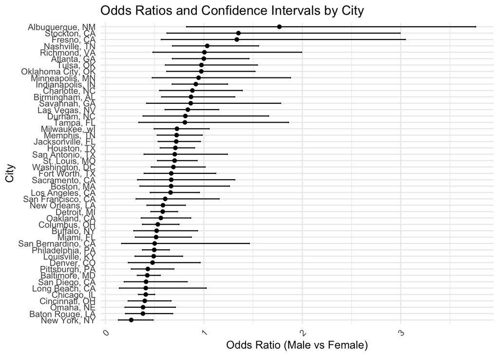

```r
##Create a plot that shows the estimated ORs and CIs for each city. Organize cities according to estimated OR, and comment on the plot.

eachcity<- eachcity %>%
  arrange(OR)
ggplot(eachcity, aes(x = reorder(city_state, OR), y = OR)) +
  geom_point() +  # Add points for ORs
  geom_errorbar(aes(ymin = CI_low, ymax = CI_high), width = 0.2) +
  coord_flip() +
  labs(x = "City", y = "Odds Ratio (Male vs Female)", title = "Odds Ratios and Confidence Intervals by City") +
  theme_minimal() +
  theme(axis.text.x = element_text(angle = 45, hjust = 1))
```

Cities with an Odds Ratio (OR) greater than 1 suggest no significant difference in the resolution rates between male and female victims. Albuquerque, NM shows the highest OR along with the broadest 95% confidence interval. Other cities like Stockton, CA, and Fresno, CA also display notably high ORs above 1.

##Promblem 3

```r
#Load and clean the data for regression analysis
birthweight_df <- read_csv("data/birthweight.csv")
birthweight_df <- birthweight_df %>%
  janitor::clean_names() %>%
  mutate(
    babysex = case_when(
      babysex == 1 ~ "male",
      babysex == 2 ~ "female"
    ),
    babysex = fct_infreq(babysex),
    frace = case_when(
      frace == 1 ~ "white",
      frace == 2 ~ "black",
      frace == 3 ~ "asian",
      frace == 4 ~ "puerto rican",
      frace == 8 ~ "other"
    ),
    frace = fct_infreq(frace),
    mrace = case_when(
      mrace == 1 ~ "white",
      mrace == 2 ~ "black",
      mrace == 3 ~ "asian",
      mrace == 4 ~ "puerto rican",
      mrace == 8 ~ "other"
    ),
    mrace = fct_infreq(mrace),
        malform = as.logical(malform)
  ) %>%
  drop_na()
```

```r
#Propose a regression model for birthweight.
bw_regression_model <- lm(bwt ~ babysex + bhead + blength + delwt + fincome + frace + gaweeks + malform + menarche + mheight + momage + mrace + parity + pnumlbw + pnumsga + ppbmi + ppwt + smoken + wtgain, data = birthweight_df)

summary(bw_regression_model)
```

```
##
## Call:
## lm(formula = bwt ~ babysex + bhead + blength + delwt + fincome +
##     frace + gaweeks + malform + menarche + mheight + momage +
##     mrace + parity + pnumlbw + pnumsga + ppbmi + ppwt + smoken +
##     wtgain, data = birthweight_df)
##
## Residuals:
##      Min       1Q   Median       3Q      Max
## -1097.68  -184.86    -3.33   173.09  2344.15
##
## Coefficients: (3 not defined because of singularities)
##                     Estimate Std. Error t value Pr(>|t|)
## (Intercept)       -6265.3914   660.4011  -9.487  < 2e-16 ***
## babysexfemale        28.7073     8.4652   3.391 0.000702 ***
## bhead               130.7781     3.4523  37.881  < 2e-16 ***
## blength              74.9536     2.0217  37.075  < 2e-16 ***
## delwt                 4.1007     0.3948  10.386  < 2e-16 ***
## fincome               0.2898     0.1795   1.614 0.106551
## fraceblack           14.3313    46.1501   0.311 0.756168
## fracepuerto rican   -46.9962    44.6782  -1.052 0.292912
## fraceasian           21.2361    69.2960   0.306 0.759273
## fraceother            4.2969    74.0741   0.058 0.953745
## gaweeks              11.5494     1.4654   7.882 4.06e-15 ***
## malformTRUE           9.7650    70.6259   0.138 0.890039
## menarche             -3.5508     2.8951  -1.226 0.220083
## mheight               9.7874    10.3116   0.949 0.342588
## momage                0.7593     1.2221   0.621 0.534418
## mraceblack         -151.4354    46.0453  -3.289 0.001014 **
## mracepuerto rican   -56.4787    45.1369  -1.251 0.210901
## mraceasian          -91.3866    71.9190  -1.271 0.203908
## parity               95.5411    40.4793   2.360 0.018307 *
## pnumlbw                   NA         NA      NA       NA
## pnumsga                   NA         NA      NA       NA
## ppbmi                 4.3538    14.8913   0.292 0.770017
## ppwt                 -3.4716     2.6121  -1.329 0.183913
## smoken               -4.8544     0.5871  -8.269  < 2e-16 ***
## wtgain                    NA         NA      NA       NA
## ---
## Signif. codes:  0 '***' 0.001 '**' 0.01 '*' 0.05 '.' 0.1 ' ' 1
##
## Residual standard error: 272.5 on 4320 degrees of freedom
## Multiple R-squared:  0.7183, Adjusted R-squared:  0.717
## F-statistic: 524.6 on 21 and 4320 DF,  p-value: < 2.2e-16
```